# Презентация по лабораторной работе №12

Программирование в командном процессоре ОС UNIX. Командные файлы

Автор

Богомолова Полина Петровна

Дата публикации

20 апреля 2026 г.

# Информация о докладчике

Богомолова Полина Петровна  
Студент, ФФМиЕН  
1032253562

# Цель работы

Изучить основы программирования в оболочке ОС UNIX/Linux и научиться писать командные файлы.

# Задание

1. Создать скрипт для резервного копирования самого себя
2. Реализовать обработку произвольного числа аргументов
3. Написать аналог команды ls
4. Подсчитать количество файлов по расширению

# Теоретическое введение

Командная оболочка (shell) — это программа для взаимодействия пользователя с ОС.

Bash позволяет:

- автоматизировать задачи
- работать с файлами и каталогами
- использовать переменные, условия и циклы

Командные файлы (.sh):

- содержат последовательность команд
- выполняются интерпретатором Bash

# 1. Резервное копирование скрипта

Был разработан скрипт, создающий резервную копию самого себя.

Основные моменты:

- используется получение пути к текущему файлу
- создаётся каталог backup
- добавляется временная метка
- выполняется архивирование с помощью tar

[figure not shown]

Создание скрипта

# Результат выполнения

После запуска скрипта:

- создаётся архив
- файл сохраняется в каталоге backup
- имя содержит дату и время

[figure not shown]

Результат

# 2. Обработка аргументов

Реализован скрипт для работы с произвольным числом аргументов.

Особенности:

- используется переменная `$@`
- применяется цикл for
- корректная обработка аргументов с пробелами

[figure not shown]

Создание скрипта

# Результат выполнения

Скрипт выводит все переданные аргументы по очереди.

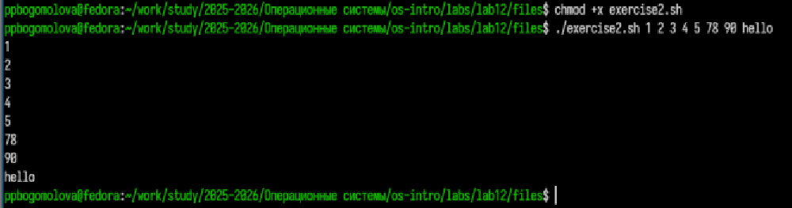

Результат

# 3. Аналог команды ls

Создан скрипт, отображающий содержимое каталога.

[figure not shown]

Создание скрипта

# Результат выполнения

Отображается:

- список файлов
- права доступа для каждого файла

[figure not shown]

Результат

# 4. Подсчёт файлов по расширению

Создан скрипт для подсчёта файлов заданного типа.

Особенности:

- передача директории и расширения через аргументы
- использование команды find
- подсчёт через wc -l

[figure not shown]

Создание скрипта

# Результат выполнения

Выводится количество файлов с заданным расширением в указанной директории.

[figure not shown]

Результат

# Выводы

В ходе лабораторной работы:

- изучены основы Bash
- освоена работа с аргументами командной строки
- реализованы циклы и условия
- получен опыт работы с файловой системой

Были приобретены навыки написания командных файлов для автоматизации задач.